# R Notebook

```r
library(vars)
library(xts)
library(stargazer)
library(forecast)
library(tidyverse)
library(lubridate)
library(tseries)
library(knitr)
library(patchwork)
library(latticeExtra)
library(TTR)
library(urca)
library(kableExtra)
library(webshot2)
library(chromote)
library(magick)
library(stringi)

Sys.setenv(CHROMOTE_CHROME = "C:/Program Files (x86)/Microsoft/Edge/Application/msedge.exe")
```

### Key ideas about time series data

Dataset is organized as quarterly values of macroeconomic and financial variables. The dataset then encompasses the different agents that exist within the economy. They each would contain their own exogenous shocks that can be portrayed as exogenous variables amongst endogenous variables. From this data we can define economic agents, their behaviors and the interdependent relationships that have with each other.

#### Fiscal Variables

1. Gross government consumption and government investment - Government Spending
2. Total public debt
3. Tax receipts
   - Total tax receipts

#### Macroeconomic Variables

1. Personal Consumption Expenditures
2. Corporate Profits
3. Capital Levels

#### Financial Variables

Certain a lot of these financial variables had to be stretched due to the observed date being on a weekend or holiday. So, the most previous value is filled in to represent the understood valuation of that market security.

1. Yields
   - 1-year
   - 5-year
   - 10-year
2. Term Premiums

Estimated by a methodology first instrumented by Adrien, Crump and Monech’s which used linear regressions to estimate the term premiums. The process makes use of principal components factors that were decomposed from the yields and then constructed regressions that represents the level, slope and convexity of the term structure. They determined that 4-5 principal components would be enough to describe the term structure using multiple market yields.

```
- 1 year
- 5 year
- 10 year
```

3. Federal Funds Rate This would influence the yields as well under the theory of the term structure. Basically the theory postulates that the yield is structured as a sum of the short term rate and a term premium

### Main data

```r
data <- read.csv("~/GitHub/Data/master_thesis_data/base_data.csv")
corps <- read.csv("~/GitHub/Data/master_thesis_data/corporate_profits_join.csv")
CPI <- read.csv("~/GitHub/Data/macro_datasets/cpi_employment.csv")


# I wrangle the convert object that has the CPI values in it and calculate the conversion
# Converting to 2013 dollars
CPI <- CPI %>%
  mutate(dates = as.Date(dates, "%m/%d/%Y"),
         conversion = CPI/234.1) %>%
  select(-c(X))

# I mutate the dates to easily merge the conversion rates, corps, and main dataset
data <- data %>%
  mutate(dates = as.Date(dates))

corps <- corps %>%
  mutate(dates = as.Date(dates))

data <- merge(data, corps)
data <- merge(data, CPI)

#Adjusting the data object for inflation here and calculate the real gdp growth and
#the real debt to gdp ratio
data <- data %>%
  mutate_at(vars(2:7, 19:22, 28, 30:35), ~.*conversion) %>%
  mutate(debt_GDP = (public_debt / gdp)) %>%
  filter(dates >= "1966-01-01")

#Calculates Second differences
change <- function(x){
  return(x - 2*lag(x) + lag(x, 2))
}

main <- data
original <- data
```

### Calculating First and Second Differences

```r
# First Difference
main[,  c(2:8, 19:22, 26:35, 37:38)] <- as.data.frame(apply(main[, c(2:8, 19:22, 26:35, 37:38)], 2, function(x) log(x) - lag(log(x))))

# Second Difference this is like the difference in the growth rates
data[,  c(2:8, 19:22, 26:35, 37:38)] <- as.data.frame(apply(data[, c(2:8, 19:22, 26:35, 37:38)], 2, change))

#Removes NAs from all columns not including the bond, note and bills columns
main <- na.omit(main[, -c(23:25)])
data <- na.omit(data[, -c(23:25)])

rm(list = c("CPI", "corps"))
```

### Stationary Tests

```r
# For First Differences
stationary_test <- as.data.frame(t(sapply(main[c(2:8, 19:32, 34:35)], adf.test)))
kable(stationary_test[,-c(2,3,5:6)])
```

|  | statistic | p.value |
| --- | --- | --- |
| current_taxes | -5.423027 | 0.01 |
| personal_inc | -3.715093 | 0.02397586 |
| employee_comp | -3.784541 | 0.02051657 |
| dis_personal_inc | -4.025752 | 0.01 |
| pce | -3.6387 | 0.03032223 |
| personal_saving | -7.822986 | 0.01 |
| population | -2.77232 | 0.2512857 |
| domestic_investment | -6.07673 | 0.01 |
| govt_spending | -3.297254 | 0.07250219 |
| fed_govt_spending | -2.627999 | 0.3119438 |
| public_debt | -3.005243 | 0.1533881 |
| private_total_workers | -6.000179 | 0.01 |
| private_average_worked_hours | -6.508653 | 0.01 |
| private_average_hourly_wages | -3.252399 | 0.07997802 |
| federal_employees | -6.263992 | 0.01 |
| firm_capital | -5.163267 | 0.01 |
| Corporate.profits.with.inventory.valuation.and.capital.consumption.adjustments | -5.308268 | 0.01 |
| Domestic.industries | -5.633987 | 0.01 |
| Financial | -5.582178 | 0.01 |
| Nonfinancial | -5.460408 | 0.01 |
| Corporate.profits.with.inventory.valuation.adjustment | -4.959527 | 0.01 |
| employment | -6.382203 | 0.01 |
| unemployment | -6.501377 | 0.01 |

```r
#For Second Differences
stationary_test <- as.data.frame(t(sapply(data[c(2:8, 19:32, 34:35)], adf.test)))
kable(stationary_test[,-c(2,3,5:6)])
```

|  | statistic | p.value |
| --- | --- | --- |
| current_taxes | -8.093028 | 0.01 |
| personal_inc | -11.70361 | 0.01 |
| employee_comp | -7.063187 | 0.01 |
| dis_personal_inc | -11.40611 | 0.01 |
| pce | -6.847578 | 0.01 |
| personal_saving | -9.710006 | 0.01 |
| population | -6.16884 | 0.01 |
| domestic_investment | -8.297455 | 0.01 |
| govt_spending | -7.670094 | 0.01 |
| fed_govt_spending | -9.914296 | 0.01 |
| public_debt | -11.16107 | 0.01 |
| private_total_workers | -8.475612 | 0.01 |
| private_average_worked_hours | -8.144327 | 0.01 |
| private_average_hourly_wages | -6.929772 | 0.01 |
| federal_employees | -10.61792 | 0.01 |
| firm_capital | -6.527331 | 0.01 |
| Corporate.profits.with.inventory.valuation.and.capital.consumption.adjustments | -9.136229 | 0.01 |
| Domestic.industries | -8.679385 | 0.01 |
| Financial | -8.401149 | 0.01 |
| Nonfinancial | -9.146594 | 0.01 |
| Corporate.profits.with.inventory.valuation.adjustment | -9.269959 | 0.01 |
| employment | -8.863458 | 0.01 |
| unemployment | -9.194868 | 0.01 |

### Proposal

Address the relationships between the variables as changes between the decisions of the agents. We luckily have the data to essentially to compute the relationships between these agents. The idea being assessed essentially is the understanding that tax levels would fluctuate due to decisions revolving around distribution of tax revenue. Considering the ideas of Ricardian equivalence, tax cuts should not affect the spending habits of consumers. Where the understanding is that if there is a tax cut in period 1, then an increase in collected tax levels in period 2 should be expected. If the consumer is rationally thinking, they would be able to conclude that they would paying that later and not now. So, the consumer would spend based on the idea that the budget constraint they operating under doesn’t change and would spend according those habits and preferences.

### Agents

1. Consumer/Households
   - We can assume that households are utility maximizing through levels of consumption and saving
2. Firms
   - We can assume that Firms are profit-maximizing by minimizing levels of labor and capital costs
3. Central Bank
   - They are in the business of ensuring economic potential via their dual mandate
4. Government
   - They provide public goods through levels of capex and labor costs based on levels of taxes

#### Households

Consumers will attempt to maximize their utility given the constraints that exist which can be the intertemporal budget function.

An intertemporal budget function relates level spending to the amount of leisure hours taken by the consumer. This can demonstrate decisions made in the short term where we consider decisions made based off information in periods 0, 1 and 2. If the household can accurately predict levels of wages for period 2 then they can consume with that expectation that tomorrow’s wages will cover the expenditures created in period 1.

$$\boldsymbol{M}_{t + 1} +
\boldsymbol{C}_{t} = \textbf{(}\boldsymbol{1}{ -
\boldsymbol{\tau}_{w}}\textbf{)}\boldsymbol{W}_{t}
+ \boldsymbol{RM}_{t}$$
Now we can see that taxes included in the budget constraint allows the change in government policy to affect attainable utility. Presumably government purchases should affect the levels of consumption, however, according to Ricardian Equivalence changes in how the government funds itself should not directly impact the consumption choices of the household. We can see that vividly in the household’s Euler function that depicts the relationship of consumption between each periods, the calculation is depicted in the paper and at no point does the tax enter into the Euler function.

$$\boldsymbol{\gamma}_{\textbf{C}} =
\frac{\boldsymbol{C'}}{\boldsymbol{C}_{t}} =
\theta\textbf{[}\boldsymbol{f'}\textbf{(}\boldsymbol{k}_{t}\textbf{)}-\boldsymbol{\rho}\textbf{]}$$

If spending can be considered consumption then the personal consumption expenditures can be utilized to describe the way households expend their incomes. The difference between the total income and the dollar amount of consumed goods can be considered what was saved or invested. Levels of investment would influences the way that firms are able to perform especially how recently the retirement packages have emerged to give the consumer control of the investment decisions. That would mean there originated an influx of investors that would affect the cash-flows of companies through common stock.

Income for the consumer originates from the working hours put in towards to the firm. Logically the consumer would rent out their services over to the firm, and would be in-exchange for a market wage. The market wage would fluctuate as the number of workers and changes, so supply shocks in the labor market would impact the perceived market wage.

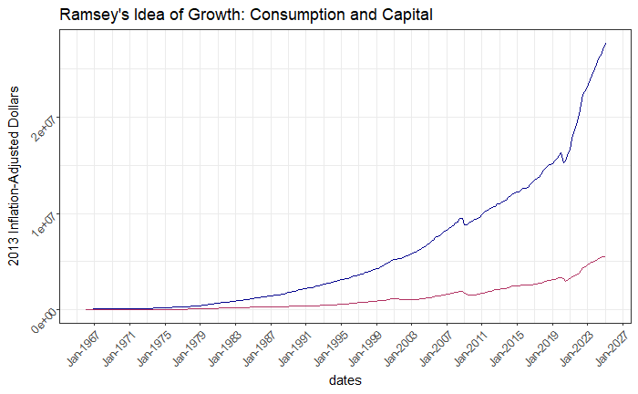

```r
ggplot(original, aes(dates, pce)) +
  geom_line(color = "darkblue") +
  geom_line(aes(y = firm_capital), color = "maroon") +
  labs(y = "2013 Inflation-Adjusted Dollars") + theme_bw() +
  ggtitle("Ramsey's Idea of Growth: Consumption and Capital") +
  scale_x_date(date_labels = "%b-%Y", date_breaks = "4 year") +
  theme(axis.text.x = element_text(angle = 45, hjust = 1),
        axis.text.y = element_text(angle = 45, hjust = 1),
        legend.position = "top")
```

```r
NA
NA
```

#### Firms

Firms will adopt a business plan that is profit maximizing, and would involve the optimization of their production function. This would be with respect to the levels of labor and capital that the firms take on. We can assume that the firms are adjusting their business plans given the levels of revenue optimized by the levels of input. The stereotypical Ramsey model stipulates the firm participates in perfectly competitive markets, so marginal costs will meet marginal revenue. That is a bold claim, however, this would not stop me from modeling profits as a function of production expenses.

$$\boldsymbol{\Pi} =
\boldsymbol{F}\textbf{(}\boldsymbol{K},\boldsymbol{AL}\textbf{)} -
\boldsymbol{wL} - \boldsymbol{RK}$$

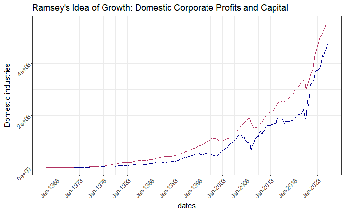

```r
ggplot(original, aes(dates, Domestic.industries)) +
  geom_line(color = "darkblue") +
  geom_line(aes(y = firm_capital), color = "maroon") +
  theme_bw() + ggtitle("Ramsey's Idea of Growth: Domestic Corporate Profits and Capital") +
  scale_x_date(date_labels = "%b-%Y", date_breaks = "5 year") +
  theme(axis.text.x = element_text(angle = 45, hjust = 1),
        axis.text.y = element_text(angle = 45, hjust = 1))
```

The above graph matches the ideas found an observation cemented in the Kaldor Facts. There is indicated that there would be a “steady rate of profit on capital”(Kaldor, 1961). Steady describes a constant average rate for the ratio and that can be indicated in the progression of the time series. The spikes and valleys mirrored each other, so the average value of the profit/capital ratio remains relatively constant across the time series. `

#### Central Bank

Central bank attempts to optimize the economy to its maximum level by implementing policy that affect levels of unemployment and changes of price. This can be represented in an augmented Philips curve that contains changes in output and unemployment on prices.

Methodologies utilized by the US central bank recently include:

1. Changing the return of lending
2. Quantitative Easing or Contracting
3. Forward Guidance

Within the context of the Neoclassical Growth Model the only social planner would be the government, however the federal funds rate will be incorporated into the empirical model as that relates the capital. Furthermore, since social planner would be the government then we would not need to add the Central Bank as a agent in the model. However, it is important to mention as a core part of the American economic system.

### 30-Day Moving Average for the Federal Funds Rate

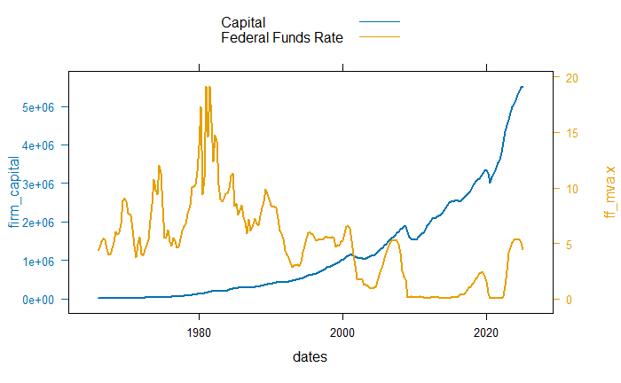

```r
yields <- read.csv("~/GitHub/Data/macro_datasets/yields_datasets.csv")
dff <- yields[,c(2, 3)]
dff <- dff %>% mutate(dates = as.Date(dates, "%m/%d/%Y"))

dff$ff_mva <- SMA(dff$DFF, n = 30)
original <- original %>%
  left_join(dff, by = join_by(dates))

doubleYScale(xyplot(firm_capital ~ dates, original, type = "l", lwd = 2),
             xyplot(ff_mva.x ~ dates, original, type = "l", lwd = 2),
             text = c("Capital", "Federal Funds Rate"), add.ylab2 = TRUE)
```